# 주제 : 공동주택 전력수요 예측 개선

- 기상변수 및 공공데이터 등 활용 공동주택 전력수요 증감 영향 요인 분석
- 계절, 지역에 따른 모델 세분화를 통한 공동주택 전력 수요 예측 (전력기상지수) 최적모델 개발
- 전력기상지수 : 기상변화에 따른 지역별 공동주택의 예상되는 전력부하 변화를 기상예보처럼 국민들이 쉽게 인지할 수 있도록 수치화하여 예측해주는 서비스

# Column Information

- num : 격자 넘버 - 기상청 동네예보 격자넘버
- tm : 날짜 - 공동주택 전력부하 측정 날짜 시간포함, 단위(0 ~ 23시)
- hh24 : 시간 - 공동주택 전력부하 측정 시간(1 ~ 24), 5시는 4시 1분 ~ 5시 00분 까지 전력 부하를 의미
- n : 공동주택 수 - 해당격자의 전력통계 산출에 포함된 공동주택의 수, 단위(단지)
- stn : 지점 번호 - AWS 지점 번호, AWS(Automated Weather Station, 자동기상관측장비)는 과거에 사람이 직접 관측하던 것을 자동으로 관측할 수 있도록 설계한 기상관측장비
- sum_qctr : 계약전력합계 - 해당격자의 전력통계 산출에 포함된 공동주택의 계약전력 합계
- sum_load : 전력수요합계 - 해당격자/시각에 측정된 공동주택의 전력수요 합계
- n_mean_load : 전력부하량평균 - 격자내 총 전력부하량을 아파트 수로 나누어 격자의 평균 부하량을 산출
- nph_ta : 기온 - 단위(C)
- nph_hm : 상대습도 - 단위(%)
- nph_ws_10m : 풍속 - 객관분석 10분 평균 풍속, 단위(m/s)
- nph_rn_60m : 강수량 - 객관분석 1시간 누적 강수량, 단위(mm)
- nph_ta_chi : 체감온도 - 단위(C)
- weekday : 요일 - 요일을 숫자형식으로 표시 월요일(0) ~ 일요일(6)
- week_name : 주중 주말 - 주중 주말을 숫자형식으로 표시, 주중(0) ~ 주말(1)
- elec : 전력기상지수(TARGET) - 해당 격자의 공동주택의 연평균 부하량을 100으로 했을 때, 해당 시작에 예상되는 부하량을 상대적인 수치로 표현

# 주의할 점

- test 데이터는 전력기상지수를 산출할 수 있는 변수인 sum_qctr, n, sum_load, n_mean_load를 제외하고 제공됨

# 데이터 & 라이브러리 불러오기

```python
import pandas as pd
import numpy as np
import seaborn as sns
import matplotlib.pyplot as plt

from xgboost import XGBRegressor
import lightgbm as lgb
from sklearn.linear_model import LinearRegression

from sklearn.metrics import mean_squared_error, r2_score

from sklearn.model_selection import GridSearchCV

import warnings
warnings.filterwarnings('ignore')
```

```python
train = pd.read_csv('/Users/jangjuik/Desktop/electric/electric_train_mac.csv', index_col = 0)
test = pd.read_csv('/Users/jangjuik/Desktop/electric/electric_test_mac.csv', index_col = 0)
```

```python
train.head()
```

|  | electric_train.num | electric_train.tm | electric_train.hh24 | electric_train.n | electric_train.stn | electric_train.sum_qctr | electric_train.sum_load | electric_train.n_mean_load | electric_train.nph_ta | electric_train.nph_hm | electric_train.nph_ws_10m | electric_train.nph_rn_60m | electric_train.nph_ta_chi | electric_train.weekday | electric_train.week_name | electric_train.elec |
| --- | --- | --- | --- | --- | --- | --- | --- | --- | --- | --- | --- | --- | --- | --- | --- | --- |
| 1 | 4821 | 2021-01-01 01:00:00 | 1 | 11 | 884 | 6950 | 751.32 | 68.606449 | 2.2 | 62.7 | 1.8 | 0.0 | -1.0 | 4 | 0 | 99.56 |
| 2 | 4821 | 2021-01-01 02:00:00 | 2 | 11 | 884 | 6950 | 692.60 | 68.606449 | 2.3 | 63.1 | 2.1 | 0.0 | -0.6 | 4 | 0 | 91.78 |
| 3 | 4821 | 2021-01-01 03:00:00 | 3 | 11 | 884 | 6950 | 597.48 | 68.606449 | 2.2 | 62.4 | 2.5 | 0.0 | -1.3 | 4 | 0 | 79.17 |
| 4 | 4821 | 2021-01-01 04:00:00 | 4 | 11 | 884 | 6950 | 553.48 | 68.606449 | 1.7 | 63.5 | 1.7 | 0.0 | -0.2 | 4 | 0 | 73.34 |
| 5 | 4821 | 2021-01-01 05:00:00 | 5 | 11 | 884 | 6950 | 526.24 | 68.606449 | 1.7 | 63.0 | 1.6 | 0.0 | -0.8 | 4 | 0 | 69.73 |

# 데이터 전처리

```python
# 컬럼명 변경
train.columns = train.columns.str.replace('electric_train.', '')
test.columns = test.columns.str.replace('electric_test.', '')

# 시간 관련 변수 생성
train['tm'] = pd.to_datetime(train['tm'], format = '%Y-%m-%d %H:%M:%S')

train['Year'] = train['tm'].dt.year
train['Month'] = train['tm'].dt.month
train['day'] = train['tm'].dt.day

test['tm'] = pd.to_datetime(test['tm'], format = '%Y-%m-%d %H:%M:%S')

test['Year'] = test['tm'].dt.year
test['Month'] = test['tm'].dt.month
test['day'] = test['tm'].dt.day
```

```python
########################################
# 결측치 처리
########################################

train.replace(-99, np.nan, inplace = True)
test.replace(-99, np.nan, inplace = True)

train = train.dropna()
```

```python
########################################
# sin, cos 시간 변수 생성
########################################

train['sin_time'] = np.sin(2 * np.pi * train.hh24 / 24)
test['sin_time'] = np.sin(2 * np.pi * test.hh24 / 24)


train['cos_time'] = np.cos(2 * np.pi * train.hh24 / 24)
test['cos_time'] = np.cos(2 * np.pi * test.hh24 / 24)
```

```python
########################################
# 불쾌지수 변수 생성
########################################

train['THI'] = 9/5 * train['nph_ta'] - 0.55 * (1 - train['nph_hm'] / 100) * (9/5 * train['nph_ta'] - 26) + 32
test['THI'] = 9/5 * test['nph_ta'] - 0.55 * (1 - test['nph_hm'] / 100) * (9/5 * test['nph_ta'] - 26) + 32
```

```python
########################################
# 기온, 습도, 이동평균 변수 생성
########################################

# 24 * 7 = 168, 7일치의 관측치를 사용하여 이동평균 계산
train['temperature_7d_ma'] = train['nph_ta'].rolling(window = 168, min_periods= 1).mean()
test['temperature_7d_ma'] = test['nph_ta'].rolling(window = 168, min_periods= 1).mean()

train['humidity_7d_ma'] = train['nph_hm'].rolling(window = 168, min_periods= 1).mean()
test['humidity_7d_ma'] = test['nph_hm'].rolling(window = 168, min_periods= 1).mean()
```

```python
########################################
# 폭염 여부
########################################

train['Heatwave'] = (train['nph_ta_chi'] >= 33).astype(int)
test['Heatwave'] = (test['nph_ta_chi'] >= 33).astype(int)

# 변수 삭제
train.drop(['tm','num', 'n', 'stn', 'sum_qctr', 'sum_load', 'n_mean_load'],axis = 1, inplace = True)
test.drop(['tm','num', 'stn'], axis = 1, inplace = True)
```

# EDA

## 1) 전력기상지수 분포

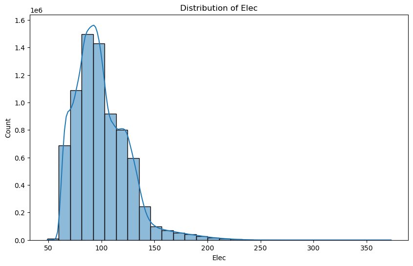

```python
plt.figure(figsize = (10, 6))
sns.histplot(train['elec'], bins = 30, kde = True)
plt.title('Distribution of Elec')
plt.xlabel('Elec')

# 데이터가 왼쪽으로 치우쳐 있음
```

## 2) 전력기상지수 평균 분포 시각화

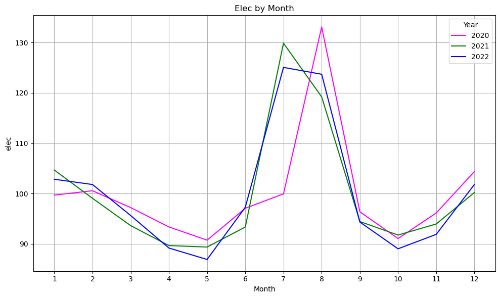

```python
# 월별 전력기상지수(elec)를 평균내어 그래프로 시각화

colors = ['magenta', 'green', 'blue']

monthly_elec = train.groupby(['Year', 'Month'])['elec'].mean()[:-1].reset_index()  # 2023년 1월 제외
grouped_data_elec = monthly_elec.groupby('Year')

plt.figure(figsize = (10,6))

for i, (year, group) in enumerate(grouped_data_elec):
    plt.plot(group['Month'], group['elec'], label = f'{year}', color = colors[i])

plt.title('Elec by Month')
plt.xlabel('Month')
plt.ylabel('elec')
plt.xticks(range(1, 13), [str(month) for month in range(1, 13)])
plt.legend(title = 'Year')
plt.grid(True)
plt.tight_layout()
plt.show()

# 여름에 전력기상지수가 높게 나타나는 것을 알 수 있음
```

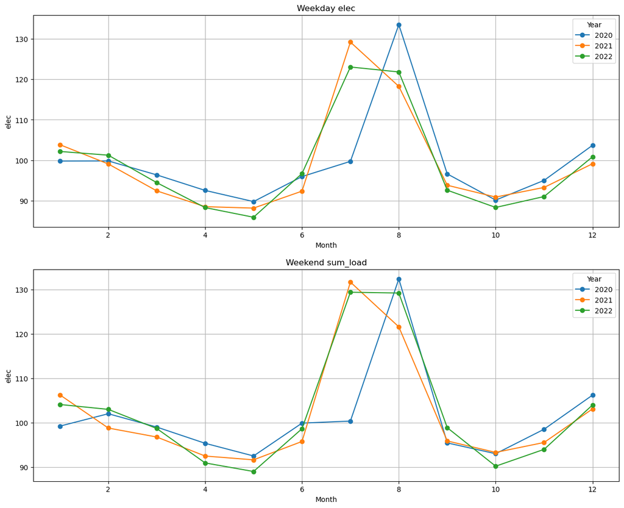

```python
# 전력기상지수(elec)를 주중과 주말로 나눠서 시각화

monthly_wn = train.groupby(['Year','Month','week_name'])['elec'].mean()[:-1].reset_index()  # 2023년 1월 1일 제외

weekday_data = monthly_wn[monthly_wn['week_name'] == 0]
weekend_data = monthly_wn[monthly_wn['week_name'] == 1]

weekday_grouped = weekday_data.groupby(['Year', 'Month']).first()
weekend_grouped = weekend_data.groupby(['Year', 'Month']).first()

fig, axes = plt.subplots(nrows = 2, ncols = 1, figsize = (15 ,12))

# 주중 그래프
for year, group in weekday_grouped.groupby(level = 0):
    axes[0].plot(group.index.get_level_values('Month'), group['elec'], marker = 'o', label = f'{year}')
axes[0].set_title('Weekday elec')
axes[0].set_xlabel('Month')
axes[0].set_ylabel('elec')
axes[0].legend(title = 'Year')
axes[0].grid(True)

# 주말 그래프
for year, group in weekend_grouped.groupby(level = 0):
    axes[1].plot(group.index.get_level_values('Month'), group['elec'], marker = 'o', label = f'{year}')
axes[1].set_title('Weekend sum_load')
axes[1].set_xlabel('Month')
axes[1].set_ylabel('elec')
axes[1].legend(title = 'Year')
axes[1].grid(True)

# 전력기상지수는 주중과 주말 비슷한 양상을 보임
```

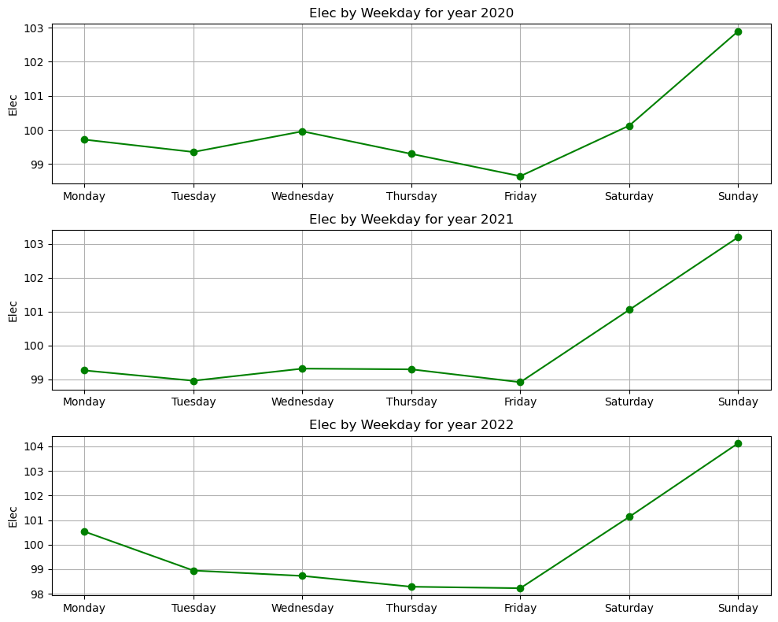

```python
# 전력기상지수(elec)를 요일별로 나눠서 시각화

day_data = train.groupby(['Year','weekday'])['elec'].mean()[:-1].reset_index() # 2023년 1월 1일 제외

fig, axes = plt.subplots(nrows = 3, ncols = 1, figsize = (10,8))

for i, year in enumerate(day_data['Year'].unique()):
    year_data = day_data[day_data['Year'] == year]
    axes[i].plot(year_data['weekday'], year_data['elec'], marker = 'o', color = 'green')
    axes[i].set_title(f'Elec by Weekday for year {year}')
    axes[i].set_ylabel('Elec')
    axes[i].set_xticks(range(7))
    axes[i].set_xticklabels(['Monday', 'Tuesday', 'Wednesday', 'Thursday', 'Friday', 'Saturday', 'Sunday'])
    axes[i].grid(True)

plt.tight_layout()
plt.show()

# 전력기상지수는 주말에 더 높게 나타나는 모습을 보임. 아마도 주말에는 출근하지 않는 사람이 많다보니 공동주택 전력수요가 증가해서 그런듯함
```

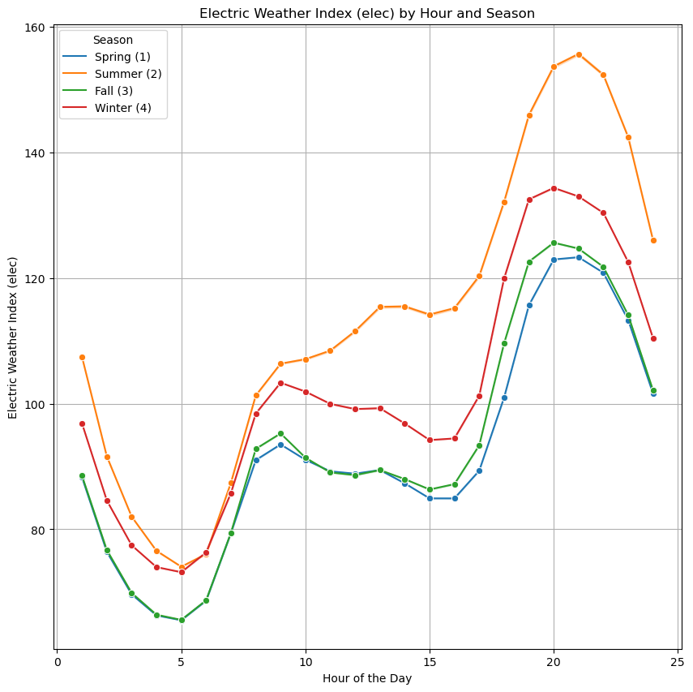

```python
# 계절별 시간대별 전력기상지수 시각화

conditions = [
    train['Month'].isin([3, 4, 5]),
    train['Month'].isin([6, 7, 8]),
    train['Month'].isin([9, 10, 11]),
    train['Month'].isin([12, 1, 2])
]

choices = [1, 2, 3, 4]

train['Season'] = np.select(conditions, choices, default=0)

plt.figure(figsize=(10,10))
plot = sns.lineplot(data=train, x='hh24', y='elec', hue='Season', palette='tab10', marker='o')

# 범례 수정
handles, labels = plot.get_legend_handles_labels()
new_labels = ['Spring (1)', 'Summer (2)', 'Fall (3)', 'Winter (4)']
plot.legend(handles=handles, labels=new_labels, title='Season')

plt.title('Electric Weather Index (elec) by Hour and Season')
plt.xlabel('Hour of the Day')
plt.ylabel('Electric Weather Index (elec)')
plt.grid(True)
plt.show()

# 여름에 전력기상지수가 가장 높게 나타나고, 그 다음으로 겨울이 높다.
```

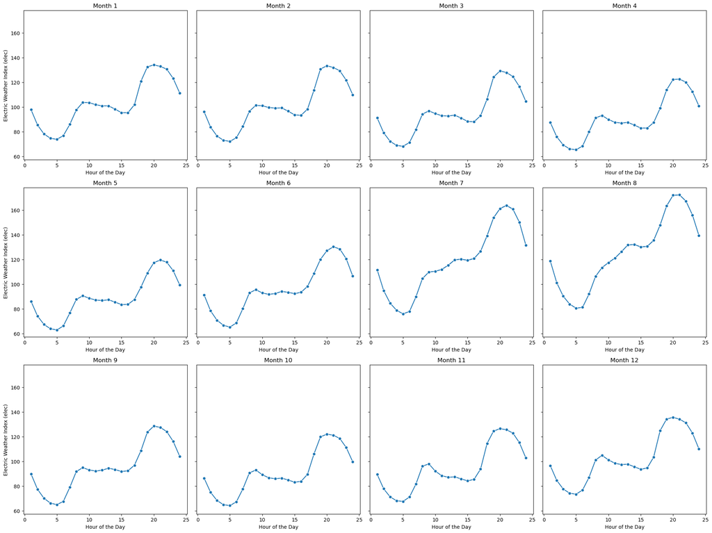

```python
# 월별 시간대에 따른 전력기상지수(elec)를 시각화

# 서브플롯 생성
fig, axes = plt.subplots(3, 4, figsize=(20, 15), sharey=True)
axes = axes.flatten()

# 각 월별로 서브플롯에 그래프 그리기
for i in range(1, 13):
    ax = axes[i - 1]
    month_data =train[train['Month'] == i]
    if not month_data.empty:
        sns.lineplot(data=month_data, x='hh24', y='elec', ax=ax, marker='o')
        ax.set_title(f'Month {i}')
        ax.set_xlabel('Hour of the Day')
        ax.set_ylabel('Electric Weather Index (elec)')
    else:
        ax.set_visible(False)

plt.tight_layout()
plt.show()

# 전력부하가 많은 7,8월에 전력기상지수가 가장 높게 나타난다.
```